# Credit Card Debt Prediction

## 1. Problem Definition

We aim to predict `Balance` (average credit card debt) for each customer based on various attributes like income, credit limit, credit rating, and demographic data.

```python
import pandas as pd
import numpy as np
import seaborn as sns
import matplotlib.pyplot as plt
from sklearn.model_selection import train_test_split
from sklearn.linear_model import LinearRegression
from sklearn.metrics import mean_squared_error, r2_score
import statsmodels.api as sm
from sklearn.preprocessing import StandardScaler
from scipy.stats import shapiro
from statsmodels.stats.outliers_influence import variance_inflation_factor
```

## Load the dataset

```python
data = pd.read_csv("Credit_assignment.csv")
data.head()
```

|  | Income | Limit | Rating | Cards | Age | Education | Own | Student | Married | Region | Balance |
| --- | --- | --- | --- | --- | --- | --- | --- | --- | --- | --- | --- |
| 0 | 14.891 | 3606 | 283 | 2 | 34 | 11 | No | No | Yes | South | 333 |
| 1 | 106.025 | 6645 | 483 | 3 | 82 | 15 | Yes | Yes | Yes | West | 903 |
| 2 | 104.593 | 7075 | 514 | 4 | 71 | 11 | No | No | No | West | 580 |
| 3 | 148.924 | 9504 | 681 | 3 | 36 | 11 | Yes | No | No | West | 964 |
| 4 | 55.882 | 4897 | 357 | 2 | 68 | 16 | No | No | Yes | South | 331 |

## Inspect dataset structure and check for missing values

```python
print(data.info())
print(data.describe())
print(data.isnull().sum())
```

```
<class 'pandas.core.frame.DataFrame'>
RangeIndex: 400 entries, 0 to 399
Data columns (total 11 columns):
 #   Column     Non-Null Count  Dtype
---  ------     --------------  -----
 0   Income     400 non-null    float64
 1   Limit      400 non-null    int64
 2   Rating     400 non-null    int64
 3   Cards      400 non-null    int64
 4   Age        400 non-null    int64
 5   Education  400 non-null    int64
 6   Own        400 non-null    object
 7   Student    400 non-null    object
 8   Married    400 non-null    object
 9   Region     400 non-null    object
 10  Balance    400 non-null    int64
dtypes: float64(1), int64(6), object(4)
memory usage: 34.5+ KB
None
           Income         Limit      Rating       Cards         Age  \
count  400.000000    400.000000  400.000000  400.000000  400.000000
mean    45.218885   4735.600000  354.940000    2.957500   55.667500
std     35.244273   2308.198848  154.724143    1.371275   17.249807
min     10.354000    855.000000   93.000000    1.000000   23.000000
25%     21.007250   3088.000000  247.250000    2.000000   41.750000
50%     33.115500   4622.500000  344.000000    3.000000   56.000000
75%     57.470750   5872.750000  437.250000    4.000000   70.000000
max    186.634000  13913.000000  982.000000    9.000000   98.000000

        Education      Balance
count  400.000000   400.000000
mean    13.450000   520.015000
std      3.125207   459.758877
min      5.000000     0.000000
25%     11.000000    68.750000
50%     14.000000   459.500000
75%     16.000000   863.000000
max     20.000000  1999.000000
Income       0
Limit        0
Rating       0
Cards        0
Age          0
Education    0
Own          0
Student      0
Married      0
Region       0
Balance      0
dtype: int64
```

## Convert categorical variables to dummy variables

```python
data = pd.get_dummies(data, columns=['Own', 'Student', 'Married', 'Region'], drop_first=True)
```

# Exploratory Data Analysis (EDA)

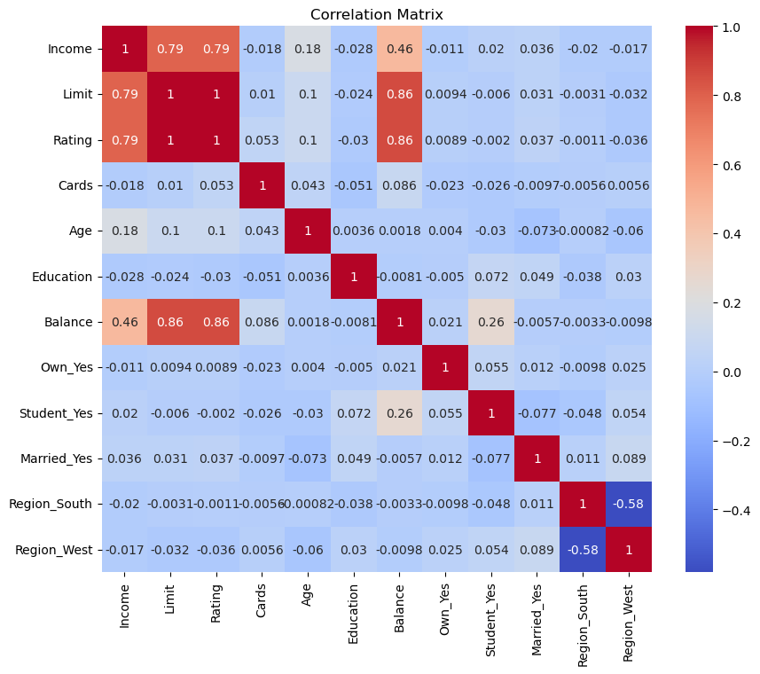

```python
plt.figure(figsize=(10, 8))
sns.heatmap(data.corr(), annot=True, cmap="coolwarm")
plt.title("Correlation Matrix")
plt.show()
```

## Pair plot to explore relationships between predictors and response variable

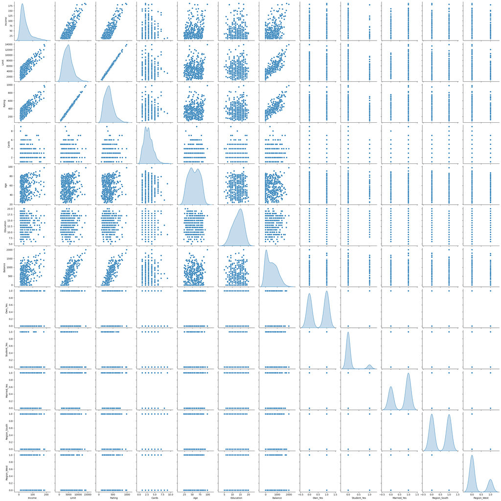

```python
sns.pairplot(data, diag_kind="kde")
plt.show()
```

## Define predictors (X) and response variable (y)

```python
X = data.drop("Balance", axis=1)
y = data["Balance"]
```

## Split the data into training and testing sets

```python
X_train, X_test, y_train, y_test = train_test_split(X, y, test_size=0.2, random_state=42)
```

## Standardize the predictor variables

```python
scaler = StandardScaler()
X_train_scaled = scaler.fit_transform(X_train)
X_test_scaled = scaler.transform(X_test)
```

## Add constant for statsmodels linear regression

```python
X_train_sm = sm.add_constant(X_train_scaled)

# Fit the model and display summary
model = sm.OLS(y_train, X_train_sm).fit()
print(model.summary())
```

```
                            OLS Regression Results
==============================================================================
Dep. Variable:                Balance   R-squared:                       0.955
Model:                            OLS   Adj. R-squared:                  0.954
Method:                 Least Squares   F-statistic:                     597.4
Date:                Fri, 01 Nov 2024   Prob (F-statistic):          2.13e-200
Time:                        16:16:15   Log-Likelihood:                -1926.6
No. Observations:                 320   AIC:                             3877.
Df Residuals:                     308   BIC:                             3922.
Df Model:                          11
Covariance Type:            nonrobust
==============================================================================
                 coef    std err          t      P>|t|      [0.025      0.975]
------------------------------------------------------------------------------
const        518.8250      5.678     91.372      0.000     507.652     529.998
x1          -266.4121      9.779    -27.243      0.000    -285.654    -247.170
x2           474.3880     89.313      5.312      0.000     298.648     650.128
x3           155.8745     89.950      1.733      0.084     -21.120     332.869
x4            26.5251      6.970      3.805      0.000      12.809      40.241
x5           -10.2107      5.834     -1.750      0.081     -21.690       1.269
x6            -3.4132      5.765     -0.592      0.554     -14.758       7.931
x7            -6.2458      5.712     -1.094      0.275     -17.484       4.993
x8           121.9658      5.759     21.178      0.000     110.634     133.298
x9            -3.0091      5.824     -0.517      0.606     -14.469       8.450
x10            5.7568      7.020      0.820      0.413      -8.057      19.571
x11            5.8273      7.085      0.822      0.411      -8.114      19.769
==============================================================================
Omnibus:                       18.681   Durbin-Watson:                   1.983
Prob(Omnibus):                  0.000   Jarque-Bera (JB):               20.945
Skew:                           0.623   Prob(JB):                     2.83e-05
Kurtosis:                       2.870   Cond. No.                         37.2
==============================================================================

Notes:
[1] Standard Errors assume that the covariance matrix of the errors is correctly specified.
```

## Plot histogram and QQ plot to check normality of residuals

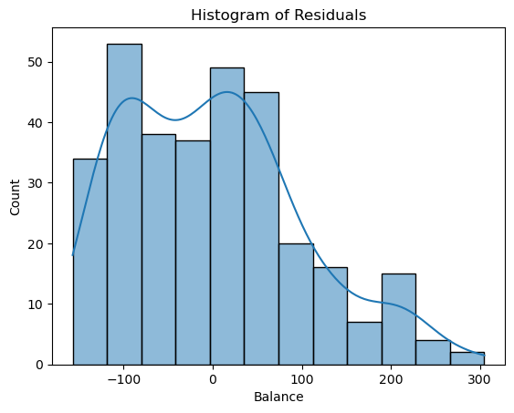

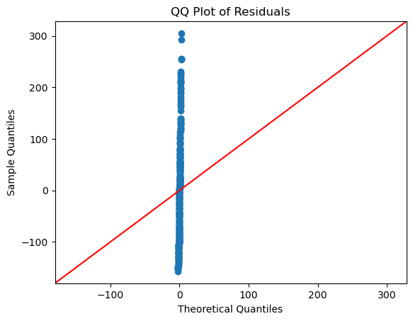

```python
sns.histplot(residuals, kde=True)
plt.title("Histogram of Residuals")
plt.show()

sm.qqplot(residuals, line="45")
plt.title("QQ Plot of Residuals")
plt.show()
```

Ideally, residuals should follow a normal (bell-shaped) distribution, centered around zero. But the histogram shows skewness, it might imply that the model is systematically over- or under-predicting for certain values, possibly indicating the need for data transformation or more complex models.

The QQ plot compares the quantiles of the residuals to the quantiles of a theoretical normal distribution. Ideally, the points should fall along a 45-degree line, meaning the residuals closely follow a normal distribution. But our graph indicates that your residuals do not follow a normal distribution, deviating significantly from the 45-degree line expected in a normal QQ plot.

## Perform Shapiro-Wilk test for normality

```python
shapiro_test = shapiro(residuals)
print("Shapiro-Wilk Test p-value:", shapiro_test.pvalue)
```

```
Shapiro-Wilk Test p-value: 4.680319326761673e-08
```

The Shapiro-Wilk Test results indicate that the residuals from your regression model are not normally distributed

```python
# Calculate Variance Inflation Factor (VIF) to check for multicollinearity
vif_data = pd.DataFrame()
vif_data["feature"] = X.columns
vif_data["VIF"] = [variance_inflation_factor(X_train_scaled, i) for i in range(X_train_scaled.shape[1])]
print("Variance Inflation Factors (VIF):")
print(vif_data)
```

```
Variance Inflation Factors (VIF):
         feature         VIF
0         Income    2.966037
1          Limit  247.405410
2         Rating  250.951704
3          Cards    1.506951
4            Age    1.055612
5      Education    1.030961
6        Own_Yes    1.011789
7    Student_Yes    1.028699
8    Married_Yes    1.051971
9   Region_South    1.528590
10   Region_West    1.557021
```

Severe Multicollinearity:

Limit (VIF = 247.41) and Rating (VIF = 250.95): These two features exhibit severe multicollinearity with extremely high VIF values. Their inclusion in the model may distort the estimated coefficients and inflate standard errors, making them unreliable for inference. We must consider removing one or both of these variables, or combining them if they capture similar information.

```python
# Make predictions on the test set
X_test_sm = sm.add_constant(X_test_scaled)
y_test_pred = model.predict(X_test_sm)

# Calculate RMSE and R-squared
mse = mean_squared_error(y_test, y_test_pred)
rmse = np.sqrt(mse)
r2 = r2_score(y_test, y_test_pred)

print("Test RMSE:", rmse)
print("Test R-squared:", r2)
```

```
Test RMSE: 89.3020517655732
Test R-squared: 0.9522674050276406
```

A Test RMSE of 89.30 and a Test R-squared of 0.95 indicate strong model performance, suggesting that the model explains about 95% of the variance in the credit card debt prediction.